# Covid Country Analysis

#### Confirmed last week

```r
boxplot.stats(df$Confirmed.last.week)
```

**$stats**

1. 10

2. 1039

3. 4784

4. 36936

5. 88402

**$n**

182

**$conf**

1. 579.836978210999

2. 8988.163021789

**$out**

1. 130774

2. 207453

3. 2118646

4. 333029

5. 204005

6. 214023

7. 203325

8. 1155338

9. 276202

10. 94693

11. 244624

12. 349396

13. 266096

14. 357681

15. 107037

16. 776212

17. 253349

18. 373628

19. 264836

20. 220572

21. 3834677

22. 296944

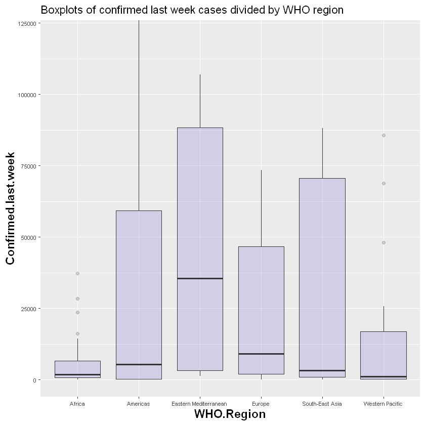

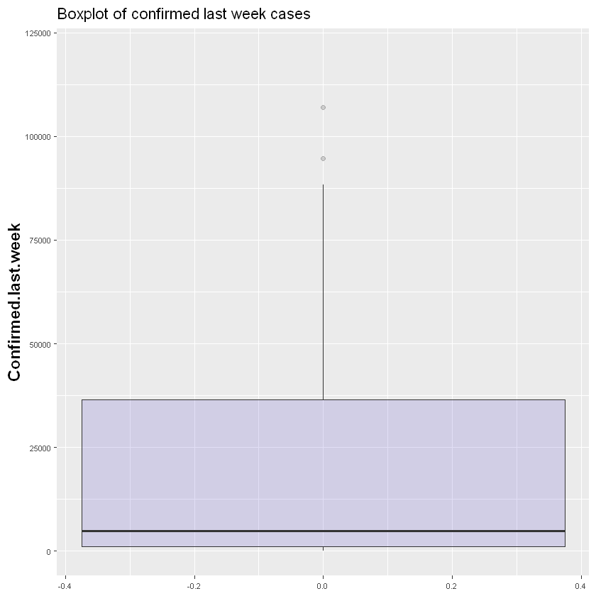

```r
ggplot(df, aes(x=as.factor(WHO.Region), y=Confirmed.last.week)) +
    geom_boxplot(fill="slateblue", alpha=0.2) +
    ggtitle("Boxplots of confirmed last week cases divided by WHO region") +
    theme(
        axis.text=element_text(size=6.5),
        axis.title=element_text(size=14, face="bold")
    ) +
    coord_cartesian(ylim = c(0, 120000)) +
    xlab("WHO.Region")

ggplot(df, aes(y=Confirmed.last.week)) +
    geom_boxplot(fill="slateblue", alpha=0.2) +
    ggtitle("Boxplot of confirmed last week cases") +
    theme(
        axis.text=element_text(size=6.5),
        axis.title=element_text(size=14, face="bold")
    ) +
    coord_cartesian(ylim = c(0, 120000))
```

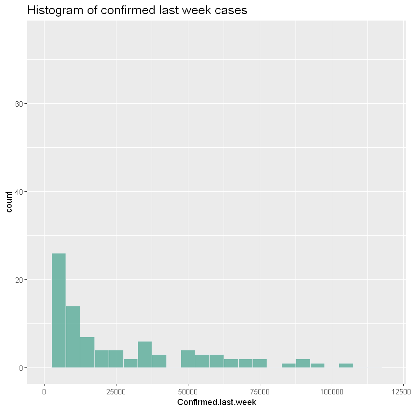

```r
ggplot(df, aes(x=Confirmed.last.week)) +
    geom_histogram( binwidth=5000, fill="#69b3a2", color="#e9ecef", alpha=0.9, position = 'identity') +
    ggtitle("Histogram of confirmed last week cases") +
    theme(plot.title = element_text(size=15)) +
    xlim(0,120000)
```

```r
png(filename = "img/Confirmed_last_week_conditional_boxplot.png", units="in", width=5, height=5, res=300)

ggplot(df, aes(x=as.factor(WHO.Region), y=Confirmed.last.week)) +
    geom_boxplot(fill="slateblue", alpha=0.2) +
    ggtitle("Boxplots of confirmed last week cases divided by WHO region") +
    theme(
        axis.text=element_text(size=6.5),
        axis.title=element_text(size=14,face="bold")
    ) +
    coord_cartesian(ylim = c(0, 120000)) +
    xlab("WHO.Region")

dev.off()

png(filename = "img/Confirmed_last_week_boxplot.png", units="in", width=5, height=5, res=300)

ggplot(df, aes(y=Confirmed.last.week)) +
    geom_boxplot(fill="slateblue", alpha=0.2) +
    ggtitle("Boxplot of confirmed last week cases") +
    theme(
        axis.text=element_text(size=6.5),
        axis.title=element_text(size=14, face="bold")
    ) +
    coord_cartesian(ylim = c(0, 120000))

dev.off()

png(filename = "img/Confirmed_last_week_histogram.png", units="in", width=5, height=5, res=300)

ggplot(df, aes(Confirmed.last.week)) +
    geom_histogram( binwidth=5000, fill="#69b3a2", color="#e9ecef", alpha=0.9) +
    ggtitle("Histogram of confirmed last week cases") +
    theme(plot.title = element_text(size=15)) +
    xlim(0,120000)

dev.off()
```

**png:** 2

**png:** 2

**png:** 2

#### 1 week change

```r
boxplot.stats(df$X1.week.change)
```

**$stats**

1. -47

2. 47

3. 418

4. 3325

5. 8193

**$n**

182

**$conf**

1. 34.0891889176158

2. 801.910811082384

**$out**

1. 36642

2. 18772

3. 10190

4. 323729

5. 14894

6. 53096

7. 10200

8. 324735

9. 12089

10. 17404

11. 17892

12. 11982

13. 11180

14. 46093

15. 8658

16. 32036

17. 13142

18. 40468

19. 15585

20. 78901

21. 455582

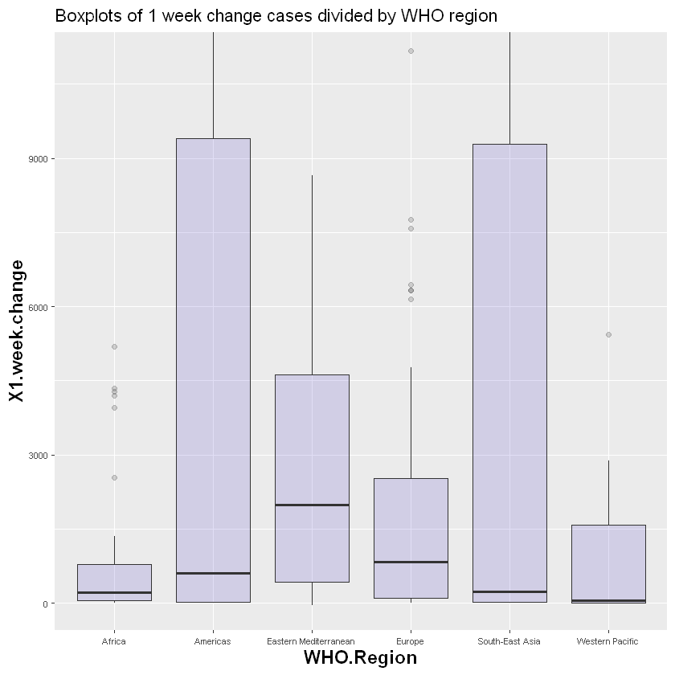

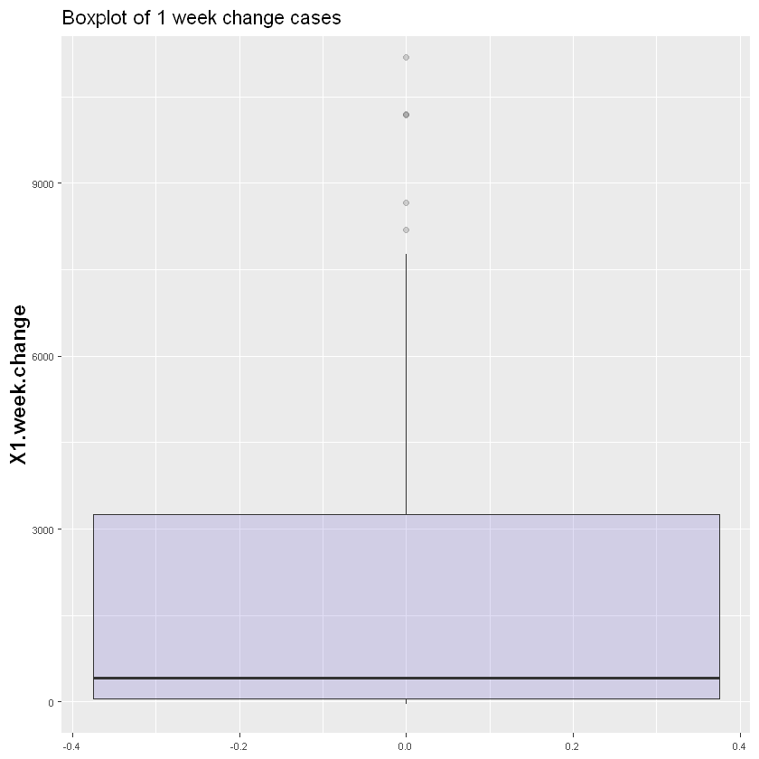

```r
ggplot(df, aes(x=as.factor(WHO.Region), y=X1.week.change)) +
    geom_boxplot(fill="slateblue", alpha=0.2) +
    ggtitle("Boxplots of 1 week change cases divided by WHO region") +
    theme(
        axis.text=element_text(size=6.5),
        axis.title=element_text(size=14, face="bold")
    ) +
    coord_cartesian(ylim = c(0, 11000)) +
    xlab("WHO.Region")

ggplot(df, aes(y=X1.week.change)) +
    geom_boxplot(fill="slateblue", alpha=0.2) +
    ggtitle("Boxplot of 1 week change cases") +
    theme(
        axis.text=element_text(size=6.5),
        axis.title=element_text(size=14, face="bold")
    ) +
    coord_cartesian(ylim = c(0, 11000))
```

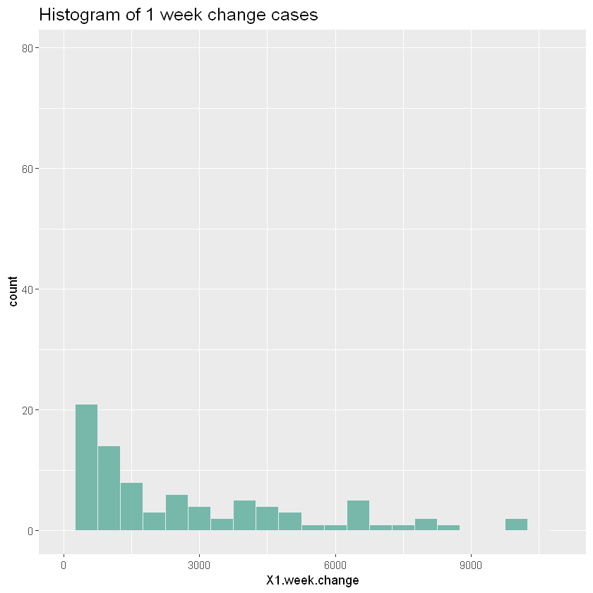

```r
ggplot(df, aes(x=X1.week.change)) +
    geom_histogram( binwidth=500, fill="#69b3a2", color="#e9ecef", alpha=0.9, position = 'identity') +
    ggtitle("Histogram of 1 week change cases") +
    theme(plot.title = element_text(size=15)) +
    xlim(0,11000)
```

```r
png(filename = "img/1_week_change_conditional_boxplot.png", units="in", width=5, height=5, res=300)

ggplot(df, aes(x=as.factor(WHO.Region), y=X1.week.change)) +
    geom_boxplot(fill="slateblue", alpha=0.2) +
    ggtitle("Boxplots of 1 week change cases divided by WHO region") +
    theme(
        axis.text=element_text(size=6.5),
        axis.title=element_text(size=14,face="bold")
    ) +
    coord_cartesian(ylim = c(0, 11000)) +
    xlab("WHO.Region")

dev.off()

png(filename = "img/1_week_change_boxplot.png", units="in", width=5, height=5, res=300)

ggplot(df, aes(y=X1.week.change)) +
    geom_boxplot(fill="slateblue", alpha=0.2) +
    ggtitle("Boxplot of 1 week change cases") +
    theme(
        axis.text=element_text(size=6.5),
        axis.title=element_text(size=14, face="bold")
    ) +
    coord_cartesian(ylim = c(0, 11000))

dev.off()

png(filename = "img/1_week_change_histogram.png", units="in", width=5, height=5, res=300)

ggplot(df, aes(X1.week.change)) +
    geom_histogram( binwidth=500, fill="#69b3a2", color="#e9ecef", alpha=0.9) +
    ggtitle("Histogram of 1 week change cases") +
    theme(plot.title = element_text(size=15)) +
    xlim(0,11000)

dev.off()
```

**png:** 2

**png:** 2

**png:** 2

#### 1 week % increase

```r
boxplot.stats(df$X1.week...increase)
```

**$stats**

1. -3.84

2. 2.75

3. 6.89

4. 17

5. 37.44

**$n**

182

**$conf**

1. 5.22107716353753

2. 8.55892283646247

**$out**

1. 119.54

2. 41.57

3. 42.52

4. 191.07

5. 40.67

6. 42.78

7. 226.32

8. 57.85

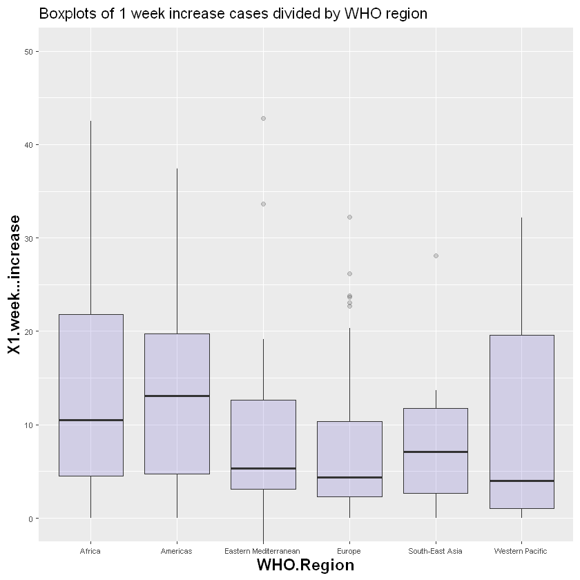

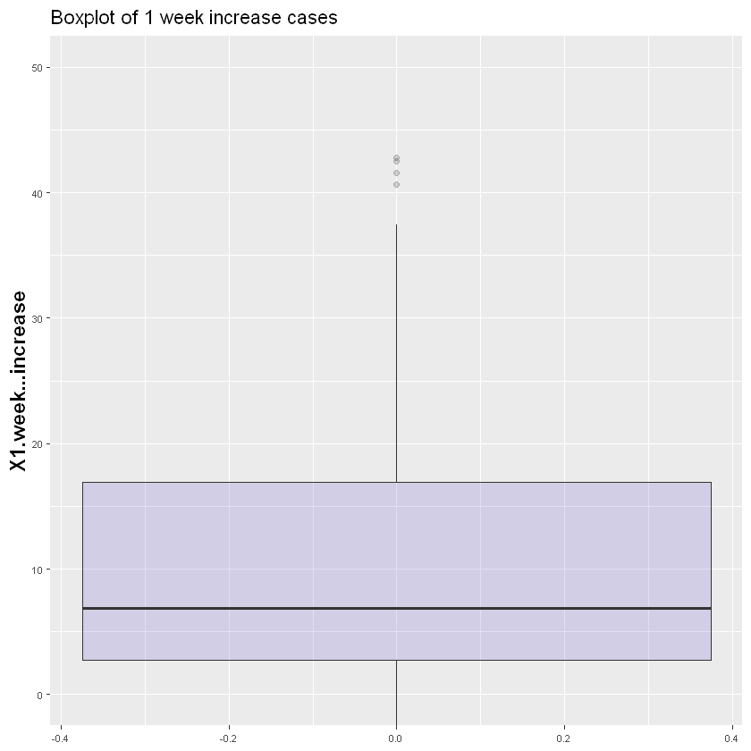

```r
ggplot(df, aes(x=as.factor(WHO.Region), y=X1.week...increase)) +
    geom_boxplot(fill="slateblue", alpha=0.2) +
    ggtitle("Boxplots of 1 week increase cases divided by WHO region") +
    theme(
        axis.text=element_text(size=6.5),
        axis.title=element_text(size=14, face="bold")
    ) +
    coord_cartesian(ylim = c(0, 50)) +
    xlab("WHO.Region")

ggplot(df, aes(y=X1.week...increase)) +
    geom_boxplot(fill="slateblue", alpha=0.2) +
    ggtitle("Boxplot of 1 week increase cases") +
    theme(
        axis.text=element_text(size=6.5),
        axis.title=element_text(size=14, face="bold")
    ) +
    coord_cartesian(ylim = c(0, 50))
```

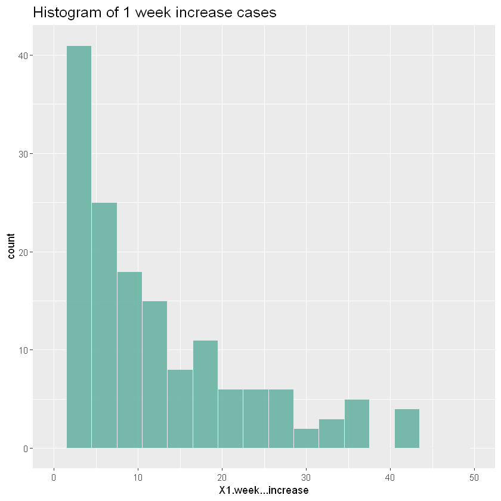

```r
ggplot(df, aes(x=X1.week...increase)) +
    geom_histogram( binwidth=3, fill="#69b3a2", color="#e9ecef", alpha=0.9, position = 'identity') +
    ggtitle("Histogram of 1 week increase cases") +
    theme(plot.title = element_text(size=15)) +
    xlim(0,50)
```

```r
png(filename = "img/1_week_increase_conditional_boxplot.png", units="in", width=5, height=5, res=300)

ggplot(df, aes(x=as.factor(WHO.Region), y=X1.week...increase)) +
    geom_boxplot(fill="slateblue", alpha=0.2) +
    ggtitle("Boxplots of 1 week increase cases divided by WHO region") +
    theme(
        axis.text=element_text(size=6.5),
        axis.title=element_text(size=14,face="bold")
    ) +
    coord_cartesian(ylim = c(0, 50)) +
    xlab("WHO.Region")

dev.off()

png(filename = "img/1_week_increase_boxplot.png", units="in", width=5, height=5, res=300)

ggplot(df, aes(y=X1.week...increase)) +
    geom_boxplot(fill="slateblue", alpha=0.2) +
    ggtitle("Boxplot of 1 week increase cases") +
    theme(
        axis.text=element_text(size=6.5),
        axis.title=element_text(size=14, face="bold")
    ) +
    coord_cartesian(ylim = c(0, 50))

dev.off()

png(filename = "img/1_week_increase_histogram.png", units="in", width=5, height=5, res=300)

ggplot(df, aes(Confirmed)) +
    geom_histogram( binwidth=3, fill="#69b3a2", color="#e9ecef", alpha=0.9) +
    ggtitle("Histogram of 1 week increase cases") +
    theme(plot.title = element_text(size=15)) +
    xlim(0,50)

dev.off()
```

**png:** 2

**png:** 2

**png:** 2

#### WHO Region

```r
table(df$WHO.Region)
```

```
               Africa              Americas Eastern Mediterranean
                   47                    34                    21
               Europe       South-East Asia       Western Pacific
                   54                    10                    16
```

### Multivariate EDA

- How does the variables jointly behave?
- Is there a correlation between confirmed cases, deaths cases and recovered cases?

```
Warning message:
"Removed 28 rows containing non-finite values (`stat_smooth()`)."
Warning message:
"Removed 28 rows containing missing values (`geom_point()`)."
```

**png:** 2

```
Warning message:
"Removed 28 rows containing non-finite values (`stat_smooth()`)."
Warning message:
"Removed 28 rows containing missing values (`geom_point()`)."
```

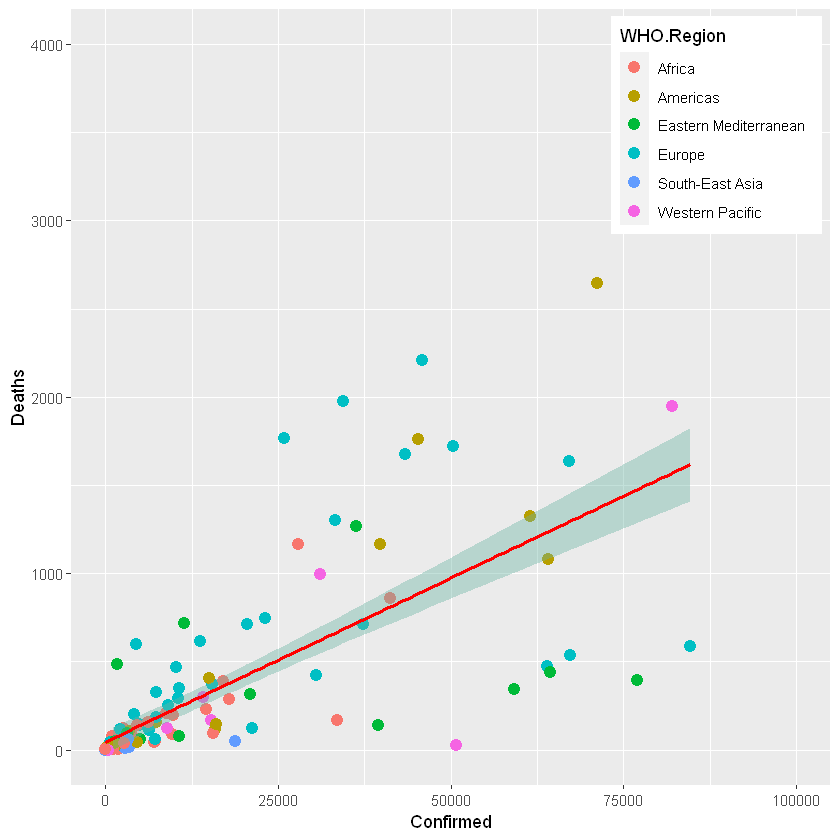

```r
png(filename = "img/Scatter_confirmed_vs_deaths.png", units="in", width=5, height=5, res=300)

ggplot(df, aes(x=Confirmed, y=Deaths, color=WHO.Region)) +
    geom_point(size=3) +
    geom_smooth(method=lm , color="red", fill="#69b3a2", se=TRUE) +
    xlim(0,100000) +
    ylim(0,4000) +
    theme(legend.position = c(0.8, 0.8))

dev.off()


ggplot(df, aes(x=Confirmed, y=Deaths, color=WHO.Region)) +
    geom_point(size=3) +
    geom_smooth(method=lm , color="red", fill="#69b3a2", se=TRUE) +
    xlim(0,100000) +
    ylim(0,4000) +
    theme(legend.position = c(0.85, 0.85))
```

```r
confirmed_deaths_lm = lm(formula = Deaths ~ Confirmed, data=df)
summary(confirmed_deaths_lm)
```

```
Call:
lm(formula = Deaths ~ Confirmed, data = df)

Residuals:
   Min     1Q Median     3Q    Max
-17907   -574   -456   -435  35034

Coefficients:
             Estimate Std. Error t value Pr(>|t|)
(Intercept) 4.393e+02  3.864e+02   1.137    0.257
Confirmed   3.437e-02  9.720e-04  35.363   <2e-16 ***
---
Signif. codes:  0 '***' 0.001 '**' 0.01 '*' 0.05 '.' 0.1 ' ' 1

Residual standard error: 5080 on 180 degrees of freedom
Multiple R-squared:  0.8742,	Adjusted R-squared:  0.8735
F-statistic:  1251 on 1 and 180 DF,  p-value: < 2.2e-16
```

```
Warning message:
"Removed 23 rows containing non-finite values (`stat_smooth()`)."
Warning message:
"Removed 23 rows containing missing values (`geom_point()`)."
```

**png:** 2

```
Warning message:
"Removed 23 rows containing non-finite values (`stat_smooth()`)."
Warning message:
"Removed 23 rows containing missing values (`geom_point()`)."
```

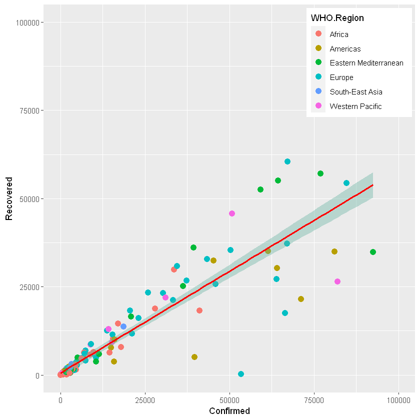

```r
png(filename = "img/Scatter_confirmed_vs_recovered.png", units="in", width=5, height=5, res=300)

ggplot(df, aes(x=Confirmed, y=Recovered, color=WHO.Region)) +
    geom_point(size=3) +
    geom_smooth(method=lm , color="red", fill="#69b3a2", se=TRUE) +
    xlim(0,100000) +
    ylim(0,100000) +
    theme(legend.position = c(0.8, 0.8))

dev.off()


ggplot(df, aes(x=Confirmed, y=Recovered, color=WHO.Region)) +
    geom_point(size=3) +
    geom_smooth(method=lm , color="red", fill="#69b3a2", se=TRUE) +
    xlim(0,100000) +
    ylim(0,100000) +
    theme(legend.position = c(0.85, 0.85))
```

```r
confirmed_recovered_lm = lm(formula = Recovered ~ Confirmed, data=df)
summary(confirmed_recovered_lm)
```

```
Call:
lm(formula = Recovered ~ Confirmed, data = df)

Residuals:
    Min      1Q  Median      3Q     Max
-615078  -11847  -11340   -5746  736621

Coefficients:
             Estimate Std. Error t value Pr(>|t|)
(Intercept) 1.186e+04  6.195e+03   1.914   0.0572 .
Confirmed   4.496e-01  1.558e-02  28.853   <2e-16 ***
---
Signif. codes:  0 '***' 0.001 '**' 0.01 '*' 0.05 '.' 0.1 ' ' 1

Residual standard error: 81440 on 180 degrees of freedom
Multiple R-squared:  0.8222,	Adjusted R-squared:  0.8212
F-statistic: 832.5 on 1 and 180 DF,  p-value: < 2.2e-16
```

**png:** 2

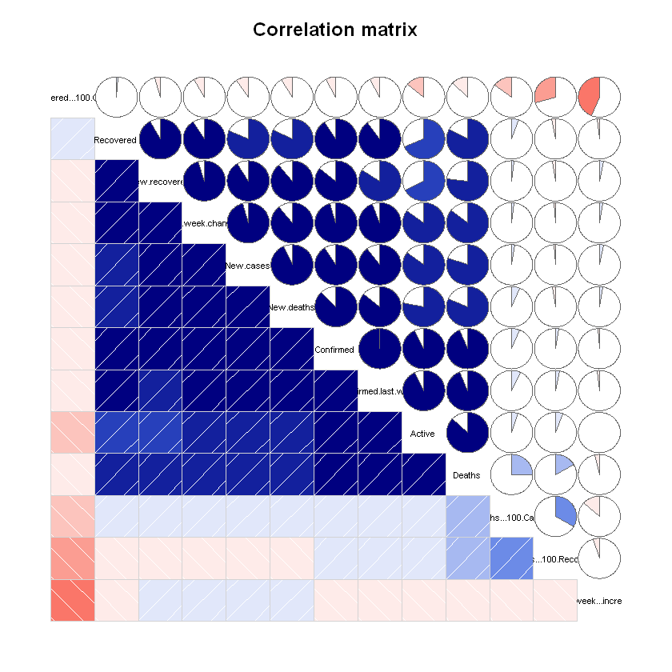

```r
df_num = df[2:14]

# First
corrgram(df_num, order=TRUE, lower.panel=panel.shade, upper.panel=panel.pie, text.panel=panel.txt, main="Correlation matrix")

png(filename = "img/Correlation_matrix.png", units="in", width=5, height=5, res=300)

corrgram(df_num, order=TRUE, lower.panel=panel.shade, upper.panel=panel.pie, text.panel=panel.txt, main="Correlation matrix")

dev.off()
```

## Dimensionality reduction

- Can the dataset be resumed by in a lower dimensional space?
- If yes, is this rappresention useful to highlight some behaviour in the data?

Let's try PCA!

```r
str(df)
```

```
'data.frame':	182 obs. of  15 variables:
 $ Country.Region        : chr  "Afghanistan" "Albania" "Algeria" "Andorra" ...
 $ Confirmed             : int  36263 4880 27973 907 950 86 167416 37390 15303 20558 ...
 $ Deaths                : int  1269 144 1163 52 41 3 3059 711 167 713 ...
 $ Recovered             : int  25198 2745 18837 803 242 65 72575 26665 9311 18246 ...
 $ Active                : int  9796 1991 7973 52 667 18 91782 10014 5825 1599 ...
 $ New.cases             : int  106 117 616 10 18 4 4890 73 368 86 ...
 $ New.deaths            : int  10 6 8 0 1 0 120 6 6 1 ...
 $ New.recovered         : int  18 63 749 0 0 5 2057 187 137 37 ...
 $ Deaths...100.Cases    : num  3.5 2.95 4.16 5.73 4.32 3.49 1.83 1.9 1.09 3.47 ...
 $ Recovered...100.Cases : num  69.5 56.2 67.3 88.5 25.5 ...
 $ Deaths...100.Recovered: num  5.04 5.25 6.17 6.48 16.94 ...
 $ Confirmed.last.week   : int  35526 4171 23691 884 749 76 130774 34981 12428 19743 ...
 $ X1.week.change        : int  737 709 4282 23 201 10 36642 2409 2875 815 ...
 $ X1.week...increase    : num  2.07 17 18.07 2.6 26.84 ...
 $ WHO.Region            : chr  "Eastern Mediterranean" "Europe" "Africa" "Europe" ...
```

```r
df_num = df[2:14]

df_scaled = scale(df_num)

corr_mat = cor(df_scaled)
eig = eigen(corr_mat)

PVE = eig$values/sum(eig$values)
PVE

cumsum(PVE)
```

1. 0.616977459780826

2. 0.123266129637276

3. 0.104685583846847

4. 0.0510483067850515

5. 0.0379863874959457

6. 0.0319526100795748

7. 0.0199390336020361

8. 0.00887849217753967

9. 0.00361606840007441

10. 0.00130097169141562

11. 0.000348956503413679

12. -7.63943361031493e-18

13. -2.45989981986085e-17

1. 0.616977459780826

2. 0.740243589418102

3. 0.844929173264948

4. 0.89597748005

5. 0.933963867545946

6. 0.965916477625521

7. 0.985855511227557

8. 0.994734003405096

9. 0.998350071805171

10. 0.999651043496586

11. 1

12. 1

13. 1

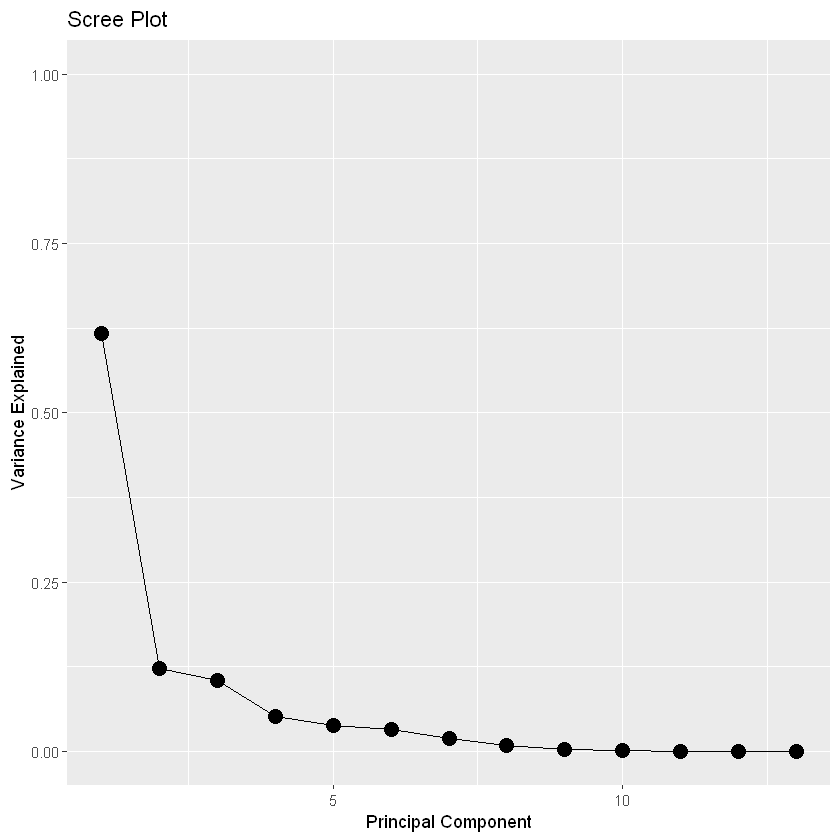

```r
df_pca = prcomp(df_scaled)

# compute total variance
variance = df_pca$sdev^2 / sum(df_pca$sdev^2)

# Scree plot
qplot(c(1:13), variance) +
  geom_line() +
  geom_point(size=4)+
  xlab("Principal Component") +
  ylab("Variance Explained") +
  ggtitle("Scree Plot") +
  ylim(0, 1)
```

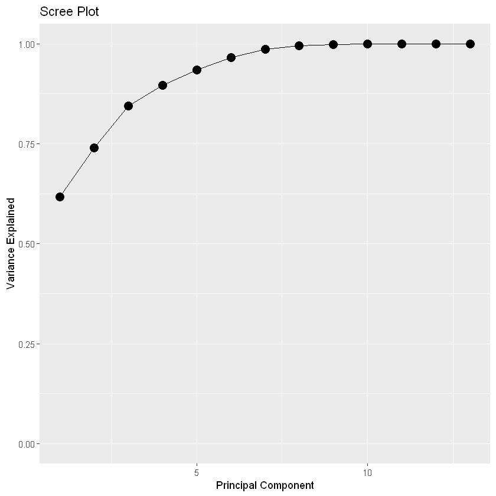

```r
# compute total variance
cum_variance = cumsum(variance)

# Scree plot
qplot(c(1:13), cum_variance) +
  geom_line() +
  geom_point(size=4)+
  xlab("Principal Component") +
  ylab("Variance Explained") +
  ggtitle("Scree Plot") +
  ylim(0, 1)
```

```r
# Kaiser rule
kaiser = df_pca$sdev^2
print(kaiser)

which(kaiser>1)
```

```
 [1] 8.020707e+00 1.602460e+00 1.360913e+00 6.636280e-01 4.938230e-01
 [6] 4.153839e-01 2.592074e-01 1.154204e-01 4.700889e-02 1.691263e-02
[11] 4.536435e-03 2.061963e-31 1.867706e-33
```

1. 1

2. 2

3. 3

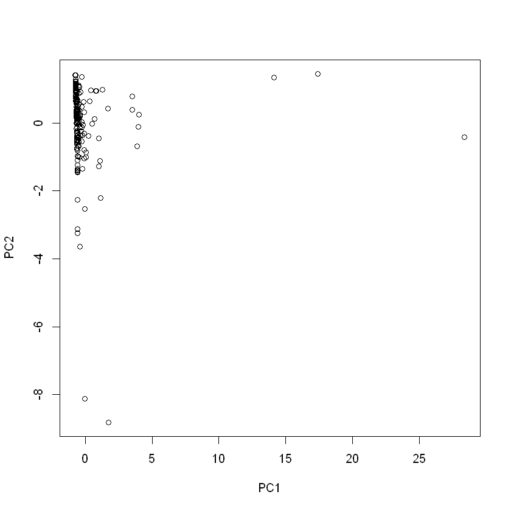

**png:** 2

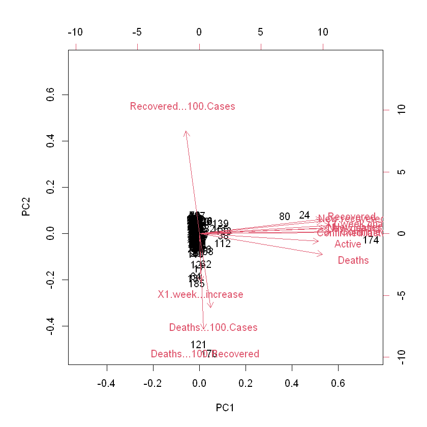

```r
#str(df_pca)

pca_scores = data.frame(df_pca$x[,1:2])
plot(pca_scores)

biplot(df_pca)

png(filename = "img/Biplot.png", units="in", width=5, height=5, res=300)

biplot(df_pca)

dev.off()
```

## Predictive Analysis

### Clustering

- Are there any hidden substructure in the data?
- If there's any, are they correspondent with WHO.Region?

Let's try to clusterize the data!

```r
k = 6
fit_kmeans <- kmeans(df_scaled, k)
```

```r
table(df$WHO.Region, fit_kmeans$cluster)
```

```
                         1  2  3  4  5  6
  Africa                 1 23  0 22  1  0
  Americas               1 14  2 14  3  0
  Eastern Mediterranean  0 13  0  6  2  0
  Europe                 0 33  0 13  6  2
  South-East Asia        0  6  1  3  0  0
  Western Pacific        1 12  0  3  0  0
```

**png:** 2

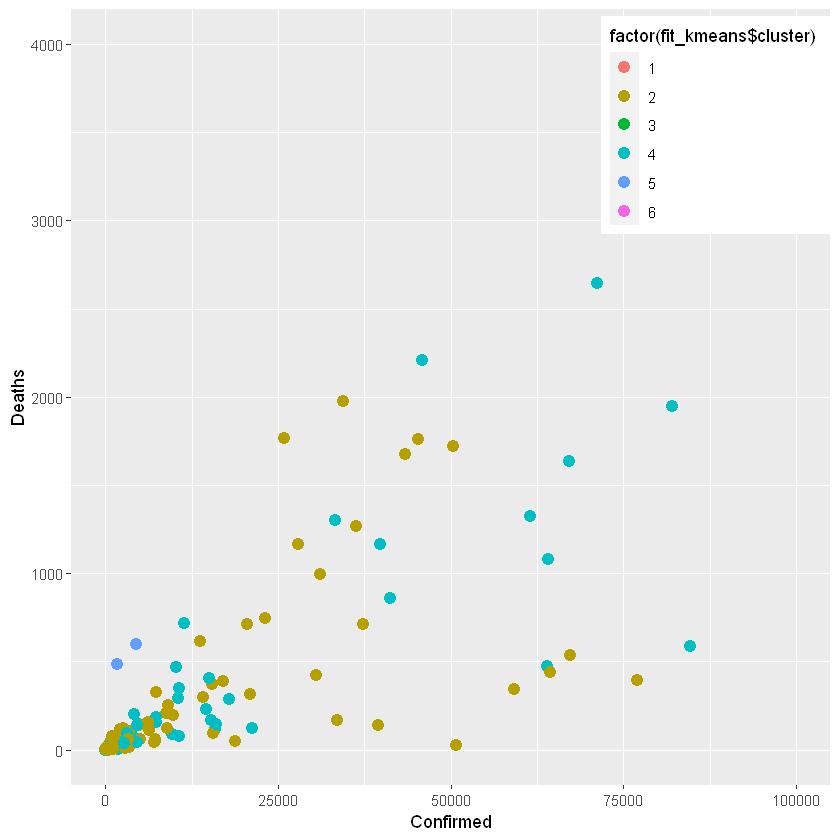

```r
ggplot(df, aes(x=Confirmed, y=Deaths, color=factor(fit_kmeans$cluster))) +
    geom_point(size=3) +
    xlim(0,100000) +
    ylim(0,4000) +
    theme(legend.position = c(0.85, 0.85))

png(filename = "img/Scatter_confirmed_vs_deaths_cluster.png", units="in", width=5, height=5, res=300)

ggplot(df, aes(x=Confirmed, y=Deaths, color=factor(fit_kmeans$cluster))) +
    geom_point(size=3) +
    xlim(0,100000) +
    ylim(0,4000) +
    theme(legend.position = c(0.85, 0.85))

dev.off()
```

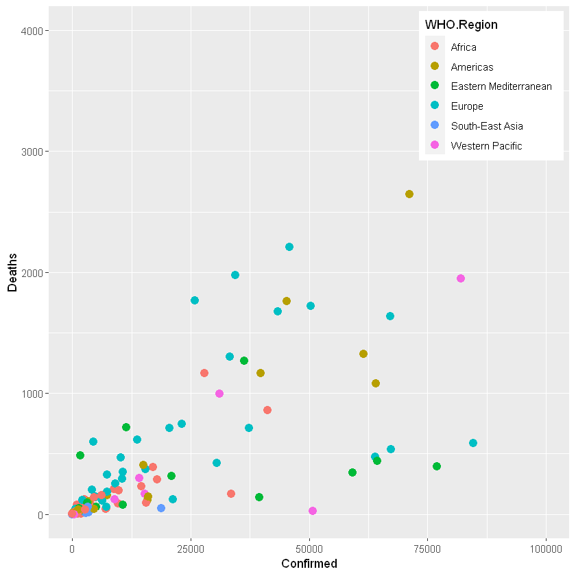

```r
ggplot(df, aes(x=Confirmed, y=Deaths, color=WHO.Region)) +
    geom_point(size=3) +
    xlim(0,100000) +
    ylim(0,4000) +
    theme(legend.position = c(0.85, 0.85))
```

```r
pca_dataframe = data.frame(df_pca$x)
```

**png:** 2

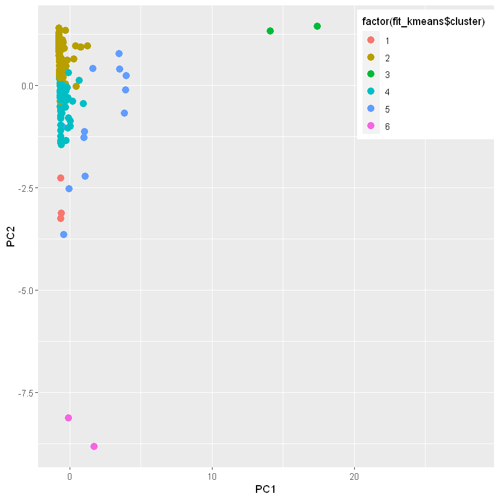

```r
ggplot(pca_dataframe, aes(x=PC1, y=PC2, color=factor(fit_kmeans$cluster))) +
    geom_point(size=3) +
    theme(legend.position = c(0.85, 0.85))

png(filename = "img/biplot_cluster.png", units="in", width=5, height=5, res=300)

ggplot(pca_dataframe, aes(x=PC1, y=PC2, color=factor(fit_kmeans$cluster))) +
    geom_point(size=3) +
    theme(legend.position = c(0.85, 0.85))

dev.off()
```

**png:** 2

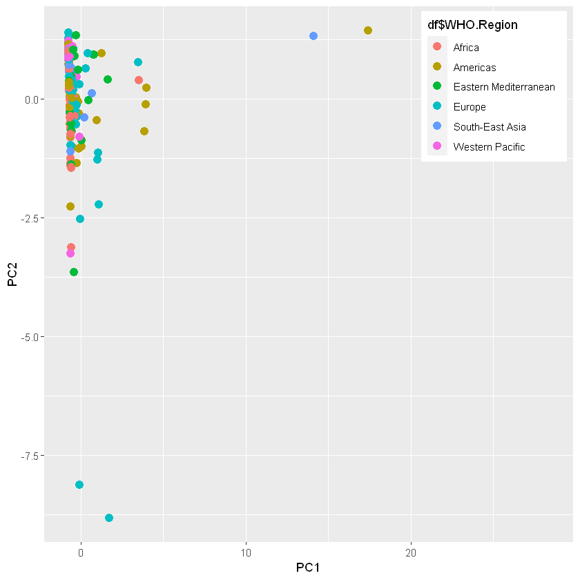

```r
ggplot(pca_dataframe, aes(x=PC1, y=PC2, color=df$WHO.Region)) +
    geom_point(size=3) +
    theme(legend.position = c(0.85, 0.85))

png(filename = "img/biplot_whoregion.png", units="in", width=5, height=5, res=300)

ggplot(pca_dataframe, aes(x=PC1, y=PC2, color=df$WHO.Region)) +
    geom_point(size=3) +
    theme(legend.position = c(0.85, 0.85))

dev.off()
```

### Linear regression

- Can we predict the deaths cases on the other values?

Let's try a linear regressor

```r
linear_model = lm(formula = Deaths ~ Confirmed + Recovered + Active + New.cases + New.deaths +
                      New.recovered + Deaths...100.Cases + Recovered...100.Cases +
                      Deaths...100.Recovered + Confirmed.last.week + X1.week.change +
                      X1.week...increase, data=df)
```

```r
summary(linear_model)
```

```
Call:
lm(formula = Deaths ~ Confirmed + Recovered + Active + New.cases +
    New.deaths + New.recovered + Deaths...100.Cases + Recovered...100.Cases +
    Deaths...100.Recovered + Confirmed.last.week + X1.week.change +
    X1.week...increase, data = df)

Residuals:
       Min         1Q     Median         3Q        Max
-3.938e-10 -1.841e-11 -1.111e-11 -5.690e-12  1.754e-09

Coefficients: (1 not defined because of singularities)
                         Estimate Std. Error    t value Pr(>|t|)
(Intercept)             3.452e-11  4.622e-11  7.470e-01    0.456
Confirmed               1.000e+00  4.228e-15  2.365e+14   <2e-16 ***
Recovered              -1.000e+00  3.073e-15 -3.254e+14   <2e-16 ***
Active                 -1.000e+00  3.133e-15 -3.191e+14   <2e-16 ***
New.cases              -5.663e-15  1.179e-14 -4.800e-01    0.632
New.deaths             -4.424e-14  3.589e-13 -1.230e-01    0.902
New.recovered           1.051e-15  2.351e-14  4.500e-02    0.964
Deaths...100.Cases      7.179e-13  3.990e-12  1.800e-01    0.857
Recovered...100.Cases  -1.770e-13  5.665e-13 -3.120e-01    0.755
Deaths...100.Recovered -5.731e-15  3.957e-14 -1.450e-01    0.885
Confirmed.last.week    -9.233e-16  2.783e-15 -3.320e-01    0.740
X1.week.change                 NA         NA         NA       NA
X1.week...increase      5.668e-14  5.230e-13  1.080e-01    0.914
---
Signif. codes:  0 '***' 0.001 '**' 0.01 '*' 0.05 '.' 0.1 ' ' 1

Residual standard error: 1.502e-10 on 170 degrees of freedom
Multiple R-squared:      1,	Adjusted R-squared:      1
F-statistic: 1.486e+29 on 11 and 170 DF,  p-value: < 2.2e-16
```